# PreLab 3: Dendrograms and Scaling on Heatmaps, and Matrix Multiplication

Introduction to Data Mathematics 2021

Jared Gridley

# Prelab Overview

In this prelab, we will:

- look in more depth at the heatmap command
- learn to do matrix algebra in R

# Setting up the Prelab

Copy `PreLab3.Rmd` to your working directory `IDM_work`. Use this for your assignment. Do a practice “knit” to html before you begin.

```r
# Read in data from the data file; create a dataframe
raw.df <- read.csv('~/MATP-4400/data/dietary_data_2005_complete.csv')


# select just fruit_raw,fruit_juice,gender,education_level and make sure factors are ordered properly and converted to numbers
D.df <- raw.df %>% select(fruit_raw,fruit_juice,gender,education_level) %>%
  mutate(gender=as.numeric(factor(gender,levels=c("male","female")))) %>%
  mutate(education_level = as.numeric(factor(education_level,
                   levels=c("pre_highschool","highschool",
                            "highschool_grad","college","college_grad"))))

# Set the rownames to be 1 to number of data points
rownames(D.df) <- 1:nrow(D.df)

# To make it run fast, we are going to take a random sample of size 30 of the data. Remove this if you want to use all the data. We set the random seed to make random sample results reproducible.
set.seed(30)

D.df <-slice_sample(D.df, n=30, replace=FALSE)

# add row names 1 to 30
rownames(D.df) <- 1:30

# make a matrix version
D.matrix<-as.matrix(D.df)
str(D.matrix)
```

```
##  num [1:30, 1:4] 82.5 0 418.9 0 0 ...
##  - attr(*, "dimnames")=List of 2
##   ..$ : chr [1:30] "1" "2" "3" "4" ...
##   ..$ : chr [1:4] "fruit_raw" "fruit_juice" "gender" "education_level"
```

# Part 1: Dendrograms and Scaling with `heatmap.2`

## A. Drawing a heatmap of a matrix with no scaling or reordering.

This command will draw the heatmap of the data as-is. Note there is no reordering of rows and columns and no scaling. If you get an error `Error in plot.new() : figure margins too large` the code is still working, but you may not see the whole graph in Rstudio and you should knit to html or pdf to see the final graph.

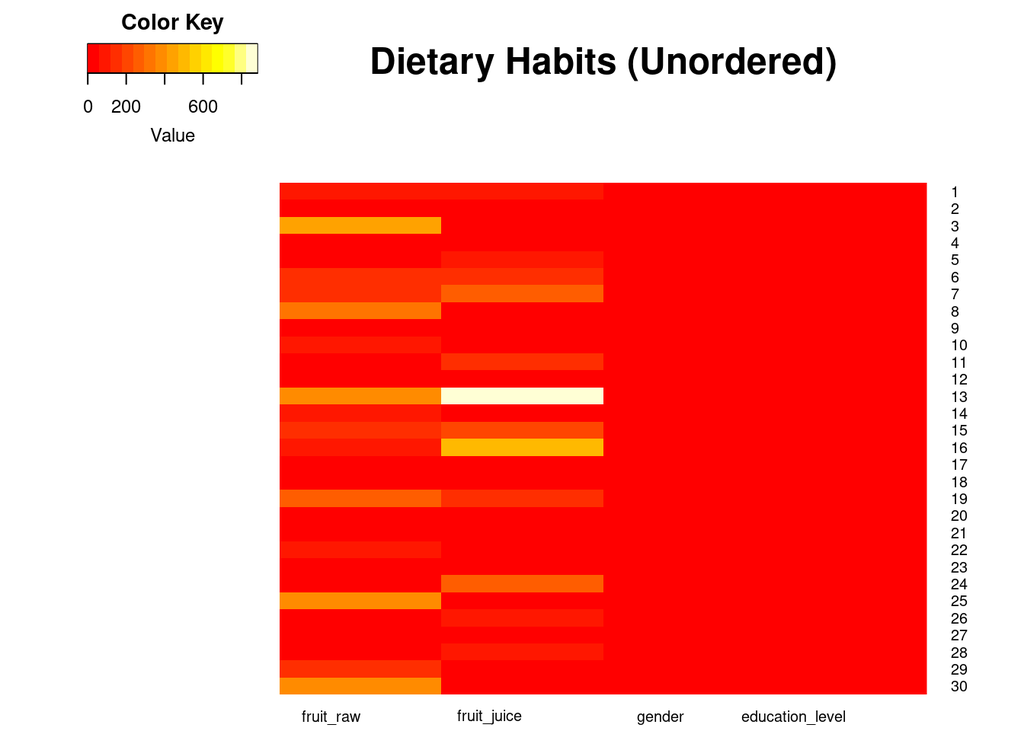

```r
heatmap.2(D.matrix,
          main='Dietary Habits (Unordered)',
          dendrogram="none",
          Rowv=FALSE,  # Don't reorder rows
          Colv=FALSE,  # Don't reorder columns
          cexRow=0.75, # Make text smaller on rows
          cexCol=0.75, # Make text smaller on columns
          lhei= c(1, 3),  # row heights
          margins = c(1.5, 4),  #plot layout
          scale="none",  # Don't scale anything
          tracecol=NA,  # nonstandard heatmap features turned off
          srtCol = 0,  # This makes the col labels horizontal
          density.info='none') # nonstandard heatmap features turned off
```